# COD Reproducibility Report

### Inferential statistics

The original authors conducted a linear mixed-effects model with choice response time as the response, described in the following text:

> A random slopes multilevel model (MLM) revealed that this relationship was significantly mediated by block (see Fig. 3; for more detailed information about the MLM fitting see Appendix A). Monolinguals were set to be the reference category for this analysis and all subsequent MLMs. The model tells us that the main-effect of group became statistically non-significant when the block-group interaction was accounted for (b = 283.11, t (64.03) = 0.71, p = 0.48). The main effect of block was also non- significant (b = 19.23, t(64.03) = 0.61, p = 0.54), meaning that the response speed of the monolinguals did not change significantly over time, when individual variation in intercepts and slopes were accounted for. The bilingual group ⁄ block interaction was signifi- cant (b = 88, t(64.03) = 2.01, p = .05), meaning that bilinguals, as a group, became faster as the task progressed.

More details about the model were provided in Appendix A:

> The multilevel regression analyses reported in this paper were conducted using the lme4 package in R (Bates, Maechler, & Bolker, 2011) Degrees of freedom and p-values were obtained using the Kenward-Roger approximation, as implemented in the pbkertest package (Halekoh & Hojsgaard, 2011)…Table A1 lists the various models we attempted to fit, Fig. A1 shows the BIC scores for all the response time models. Table A2 show the full model specification for model 3, which is the best-fitting model, and the model that is reported in the main text of the paper.

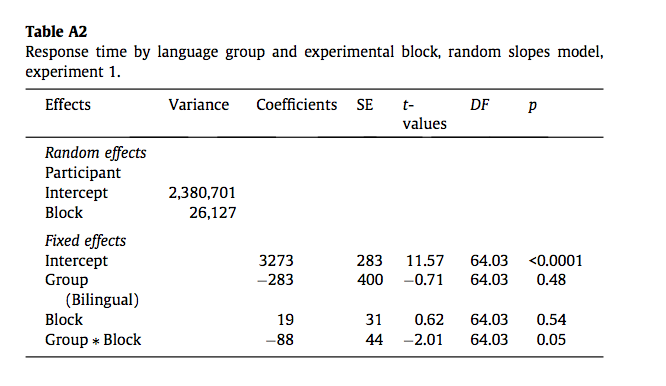

The following code chunk fits the specified model:

```r
data_tidy2 <-
  data_tidy %>%
  spread(key = measure, value = value) %>%
  gather(starts_with("rt"), key = "block", value = "rt") %>%
  mutate(block = as.numeric(str_replace(block, "rt_", "")),
         rt = 1000*rt) %>%
  left_join(demographics, by = c("id", "group")) %>%
  mutate(group = factor(group, levels = c("Monolingual","Bilingual")))

mod <- lmer(rt ~ group + block*group + (block | id), data = data_tidy2)
summary(mod)
```

```
## Linear mixed model fit by REML ['lmerMod']
## Formula: rt ~ group + block * group + (block | id)
##    Data: data_tidy2
##
## REML criterion at convergence: 7980.5
##
## Scaled residuals:
##     Min      1Q  Median      3Q     Max
## -3.9744 -0.3419 -0.0442  0.2807  7.2710
##
## Random effects:
##  Groups   Name        Variance Std.Dev. Corr
##  id       (Intercept) 2357469  1535.4
##           block         22929   151.4   -0.65
##  Residual              340296   583.3
## Number of obs: 496, groups:  id, 62
##
## Fixed effects:
##                      Estimate Std. Error t value
## (Intercept)           3272.74     287.60  11.380
## groupBilingual        -282.43     406.72  -0.694
## block                   19.25      31.64   0.608
## groupBilingual:block   -88.35      44.74  -1.975
##
## Correlation of Fixed Effects:
##             (Intr) grpBln block
## groupBilngl -0.707
## block       -0.661  0.468
## grpBlngl:bl  0.468 -0.661 -0.707
```

Compares calculated participant intercept variance to reported value:

```r
compareValues(reportedValue = 2380701, obtainedValue = 2357469)
```

```
## [1] "MINOR NUMERICAL ERROR. The reported value (2380701) and the obtained value (2357469) differed by 0.98%"
```

Compares calculated variance of block random effect to reported value:

```r
compareValues(reportedValue = 26127, obtainedValue = 22929)
```

```
## [1] "MAJOR NUMERICAL ERROR. The reported value (26127) and the obtained value (22929) differed by 12.24%"
```

Intercept: coefficient

```r
compareValues(reportedValue = 3273, obtainedValue = 3272.74)
```

```
## [1] "MINOR NUMERICAL ERROR. The reported value (3273) and the obtained value (3272.74) differed by 0.01%"
```

Intercept: SE

```r
compareValues(reportedValue = 283, obtainedValue = 287.6)
```

```
## [1] "MINOR NUMERICAL ERROR. The reported value (283) and the obtained value (287.6) differed by 1.63%"
```

Intercept: t-value

```r
compareValues(reportedValue = 11.57, obtainedValue = 11.38)
```

```
## [1] "MINOR NUMERICAL ERROR. The reported value (11.57) and the obtained value (11.38) differed by 1.64%"
```

Intercept: DF

```r
#calculated df, p value for intercept
afex::mixed(rt ~ group + block*group + (block | id),
            test_intercept = TRUE, method = "KR", data = data_tidy2)
```

```
## Fitting one lmer() model. [DONE]
## Calculating p-values. [DONE]
```

```
## Mixed Model Anova Table (Type 3 tests, KR-method)
##
## Model: rt ~ group + block * group + (block | id)
## Data: data_tidy2
##        Effect       df          F p.value
## 1 (Intercept) 1, 82.12 129.50 ***  <.0001
## 2       group 1, 82.12       0.48     .49
## 3       block 1, 65.79       0.37     .55
## 4 group:block 1, 65.79     3.90 +     .05
## ---
## Signif. codes:  0 '***' 0.001 '**' 0.01 '*' 0.05 '+' 0.1 ' ' 1
```

```r
compareValues(reportedValue = 64.03, obtainedValue = 82.12)
```

```
## [1] "MAJOR NUMERICAL ERROR. The reported value (64.03) and the obtained value (82.12) differed by 28.25%"
```

Intercept: p-value

```r
compareValues(reportedValue = .0001, obtainedValue = .0001)
```

```
## [1] "MATCH. The reported value (1e-04) and the obtained value (1e-04) differed by 0%"
```

Group: coefficient

```r
compareValues(reportedValue = -283, obtainedValue = -282.43 %>% round(0))
```

```
## [1] "MATCH. The reported value (-283) and the obtained value (-282) differed by -0.35%"
```

Group: SE

```r
compareValues(reportedValue = 400, obtainedValue = 406.72 %>% round(0))
```

```
## [1] "MINOR NUMERICAL ERROR. The reported value (400) and the obtained value (407) differed by 1.75%"
```

Group: t-value

```r
compareValues(reportedValue = -.71, obtainedValue = -0.694 %>% round(2))
```

```
## [1] "MATCH. The reported value (-0.71) and the obtained value (-0.69) differed by -2.82%"
```

Group: DF

```r
small_mod <- update(mod, .~. - group)
group_KR <- KRmodcomp(mod, small_mod)
compareValues(reportedValue = 64.03, obtainedValue = group_KR$stats$ddf)
```

```
## [1] "MAJOR NUMERICAL ERROR. The reported value (64.03) and the obtained value (82.1169369582732) differed by 28.25%"
```

Group: p-value

```r
compareValues(reportedValue = .48, obtainedValue = group_KR$stats$p.value)
```

```
## [1] "MINOR NUMERICAL ERROR. The reported value (0.48) and the obtained value (0.489388606593203) differed by 1.96%"
```

Block: coefficient

```r
compareValues(reportedValue = 19, obtainedValue = 19.25 %>% round(0))
```

```
## [1] "MATCH. The reported value (19) and the obtained value (19) differed by 0%"
```

Block: SE

```r
compareValues(reportedValue = 31, obtainedValue = 31.64 %>% round(0))
```

```
## [1] "MINOR NUMERICAL ERROR. The reported value (31) and the obtained value (32) differed by 3.23%"
```

Block: t-value

```r
compareValues(reportedValue = .62, obtainedValue = 0.608 %>% round(2))
```

```
## [1] "MINOR NUMERICAL ERROR. The reported value (0.62) and the obtained value (0.61) differed by 1.61%"
```

Block: DF

```r
small_mod <- lmer(rt ~ group + (block | id), data = data_tidy2)
block_KR <- KRmodcomp(mod, small_mod)
compareValues(reportedValue = 64.03, obtainedValue = block_KR$stats$ddf %>% round(2))
```

```
## [1] "MINOR NUMERICAL ERROR. The reported value (64.03) and the obtained value (65.79) differed by 2.75%"
```

Block: p-value

```r
compareValues(reportedValue = .54, obtainedValue = block_KR$stats$p.value %>% round(2))
```

```
## [1] "MAJOR NUMERICAL ERROR. The reported value (0.54) and the obtained value (0.08) differed by 85.19%"
```

Group*block: coefficient

```r
compareValues(reportedValue = -88, obtainedValue = -88.35 %>% round(2))
```

```
## [1] "MATCH. The reported value (-88) and the obtained value (-88.35) differed by -0.4%"
```

Group*block: SE

```r
compareValues(reportedValue = 44, obtainedValue = 44.74 %>% round(2))
```

```
## [1] "MINOR NUMERICAL ERROR. The reported value (44) and the obtained value (44.74) differed by 1.68%"
```

Group*block: t-value

```r
compareValues(reportedValue = -2.01, obtainedValue = -1.975 %>% round(2))
```

```
## [1] "MATCH. The reported value (-2.01) and the obtained value (-1.98) differed by -1.49%"
```

```r
small_mod <- lmer(rt ~ group + block + (block | id), data = data_tidy2)
interaction_KR <- KRmodcomp(mod, small_mod)
compareValues(reportedValue = 64.03, obtainedValue = interaction_KR$stats$ddf %>% round(2))
```

```
## [1] "MINOR NUMERICAL ERROR. The reported value (64.03) and the obtained value (65.79) differed by 2.75%"
```

Group*block: p-value

```r
compareValues(reportedValue = .05, obtainedValue = interaction_KR$stats$p.value %>% round(2))
```

```
## [1] "MATCH. The reported value (0.05) and the obtained value (0.05) differed by 0%"
```

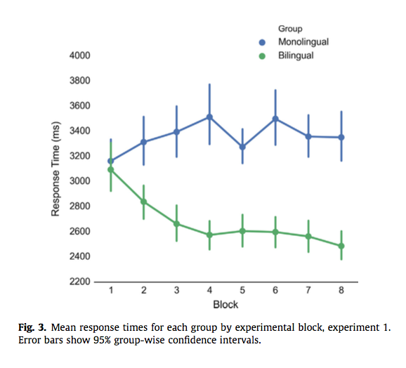

The following chunk recreates the above plot:

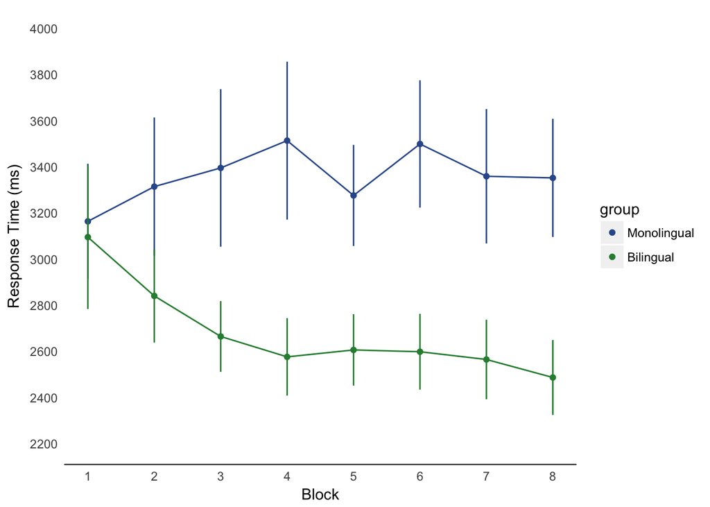

```r
data_tidy2 <-
  data_tidy %>%
  spread(key = measure, value = value) %>%
  gather(starts_with("rt"), key = "block", value = "rt") %>%
  mutate(block = str_replace(block, "rt_", ""),
         rt = 1000*rt,
         group = as.factor(group)) %>%
        # group = relevel(group, ref = "Monolingual")) %>%
  left_join(demographics, by = c("id", "group"))

data_tidy2 %>%
  mutate(group = factor(group, levels = c("Monolingual",
                                       "Bilingual")),
         block = as.integer(block)) %>%
  group_by(group, block) %>%
  summarise(avg_rt = mean(rt, na.rm = TRUE),
            se     = (sd(rt) / sqrt(n())),
            y_min = avg_rt - ((1.96 * se)/2),
            y_max = avg_rt + ((1.96 * se)/2)) %>%
  ggplot(aes(block, avg_rt, color = group)) +
  geom_point() +
  geom_line(show.legend = FALSE) +
  geom_linerange(aes(ymin = y_min, ymax = y_max), show.legend = FALSE) +
  coord_cartesian(ylim = c(2200, 4000)) +
  scale_x_continuous(breaks = seq(1, 8)) +
  scale_y_continuous(breaks = seq(2200, 4000, 200)) +
  scale_color_manual(values = c("#315a9b", "#2b8c3d")) +
  labs(x = "Block",
       y = "Response Time (ms)") +
  theme(panel.grid.major.x = element_blank(),
        panel.grid.minor.x = element_blank(),
        panel.grid.major.y = element_blank(),
        panel.grid.minor.y = element_blank(),
        panel.background = element_blank(),
        axis.line.x = element_line(),
        axis.ticks = element_blank())
```

The error bars all appear longer than those in the orginal plot. The response time means for each block appear similar.

## Step 5: Conclusion

```r
codReport(Report_Type = 'pilot',
          Article_ID = 'DvcDF',
          Insufficient_Information_Errors = 0,
          Decision_Errors = 0,
          Major_Numerical_Errors = 10,
          Minor_Numerical_Errors = 29)
```

| Insufficient_Information_Errors | Decision_Errors | Major_Numerical_Errors | Minor_Numerical_Errors | Final_Outcome |
| --- | --- | --- | --- | --- |
| 0 | 0 | 10 | 29 | Failure |

[This function will output information about the package versions used in this report:]

[output not shown]

[output cut: 168 more lines]

[output not shown]